# A simulation study based on Wilcoxon Signed Rank Test

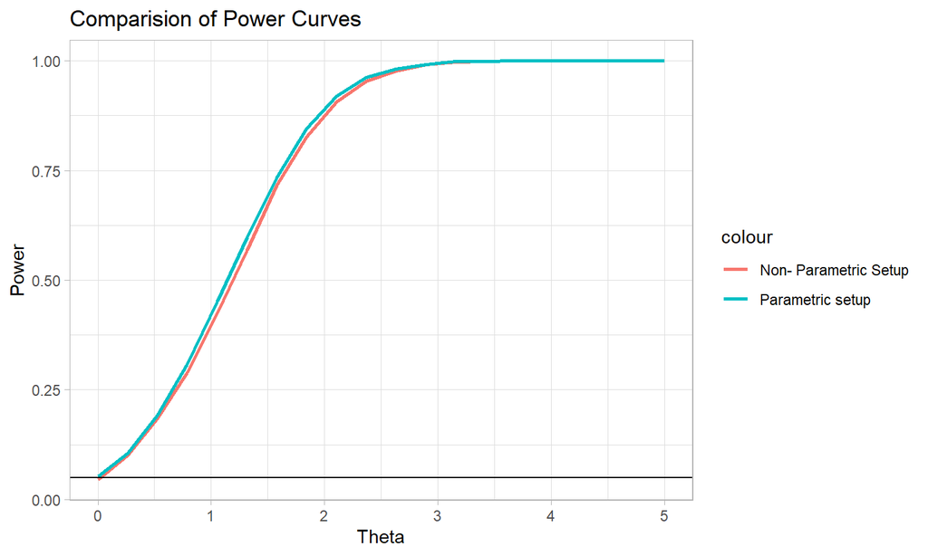

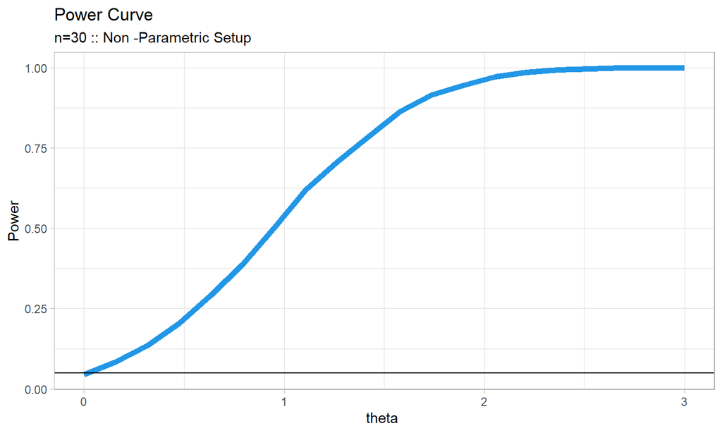

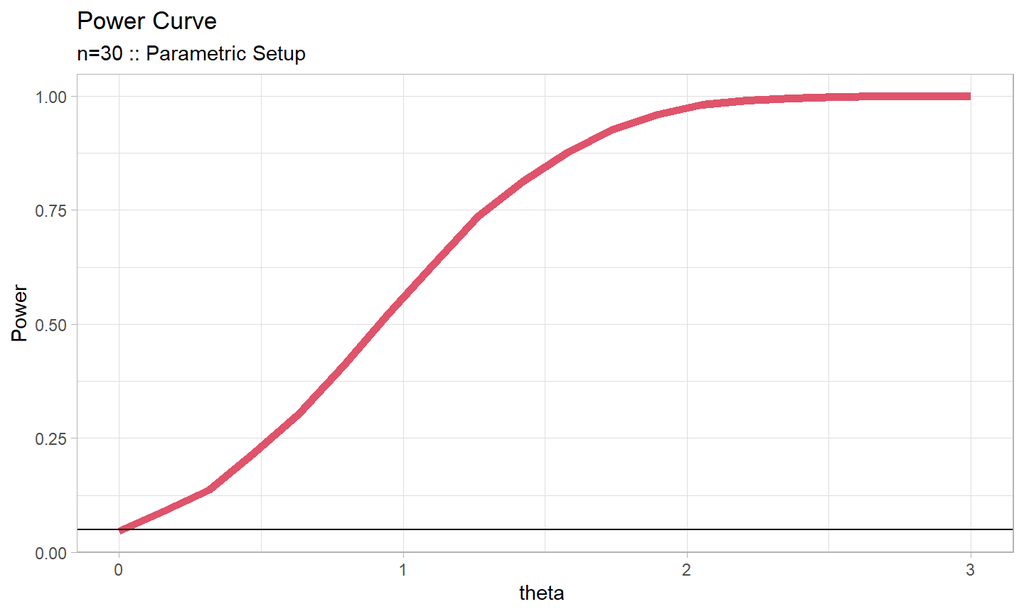

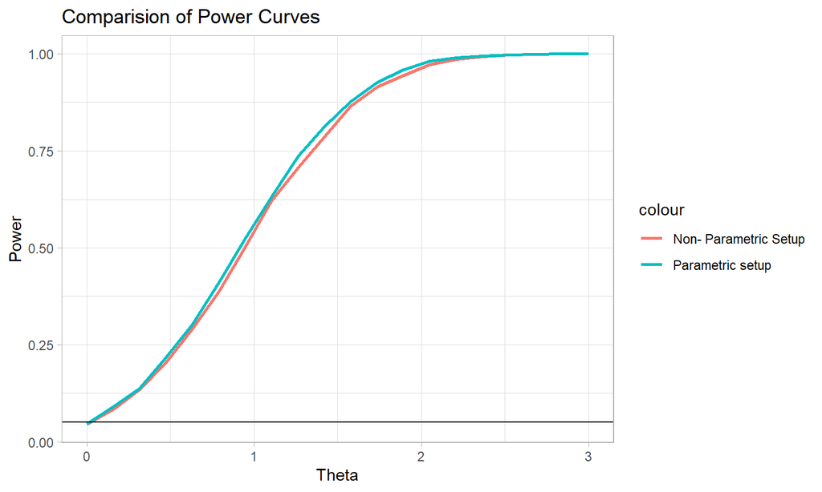

- Observation :
- Considering the t-test , the power curve for the parametric test is converging faster to unity than that of the non-parametric setup for varying sample sizes.
- Increase in sample size leads to faster rate of convergence to unity.
- Both parametric and non-parametric setup shows that the tests are unbiased.

H0 : $\mu$ = 0 vs H1 : $\mu$ $\neq$ 0 , $\sigma$ unknown

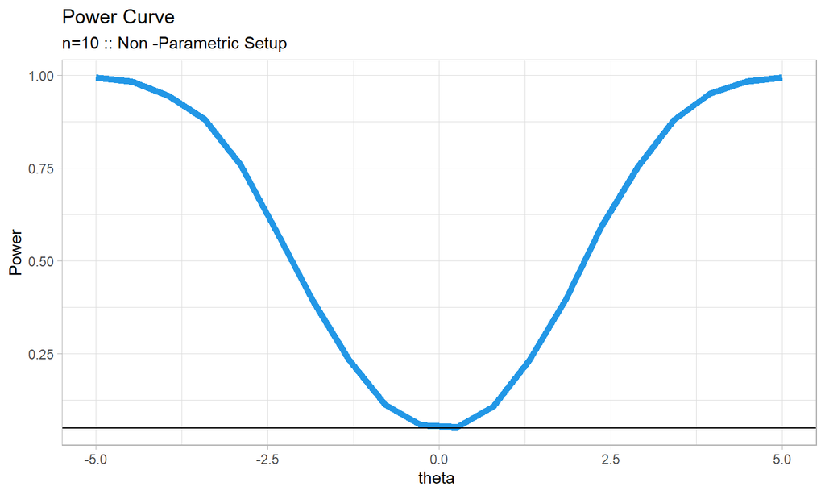

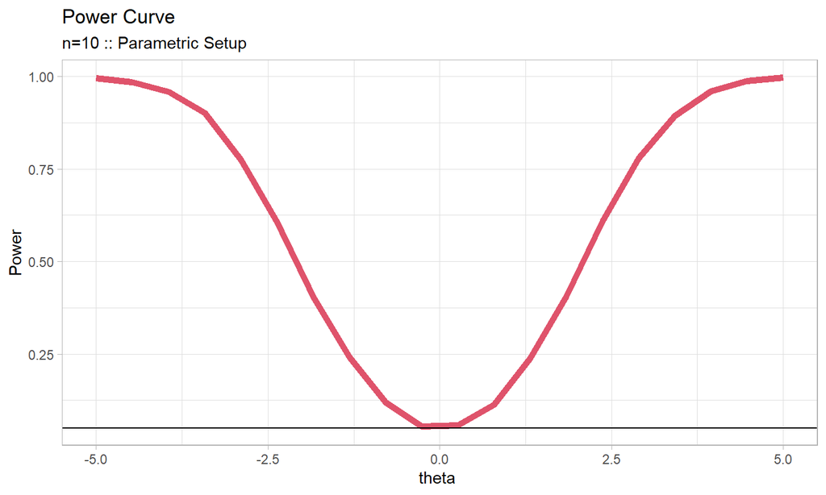

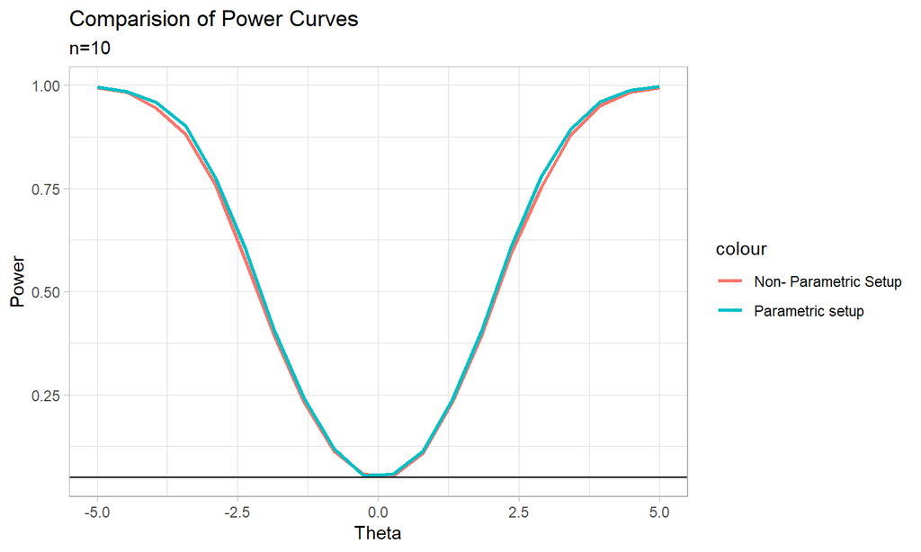

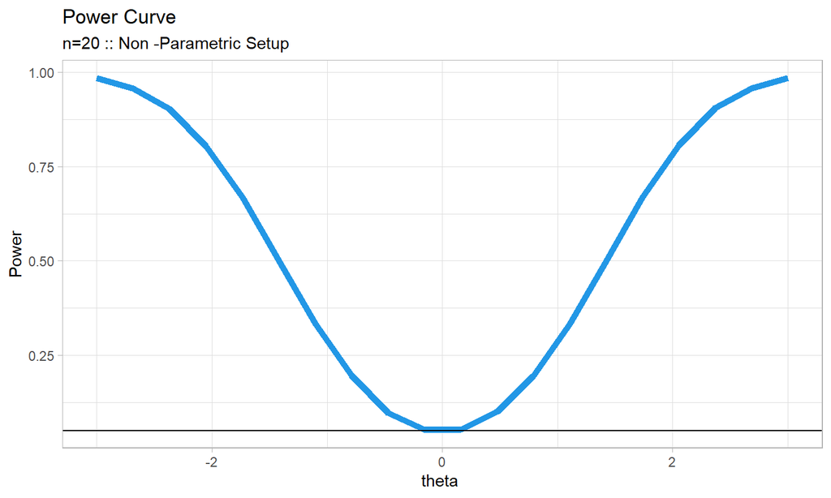

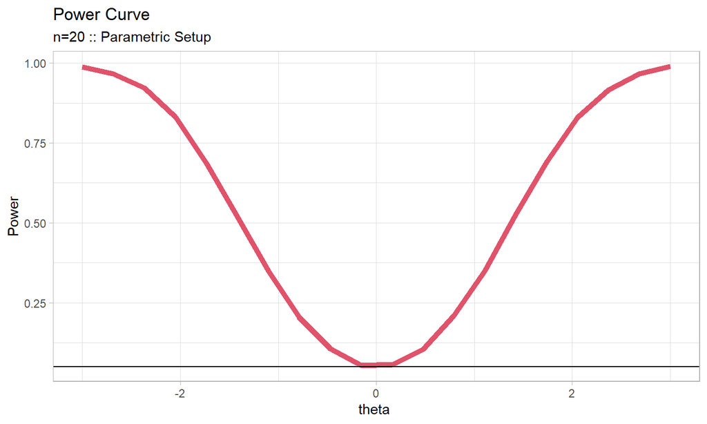

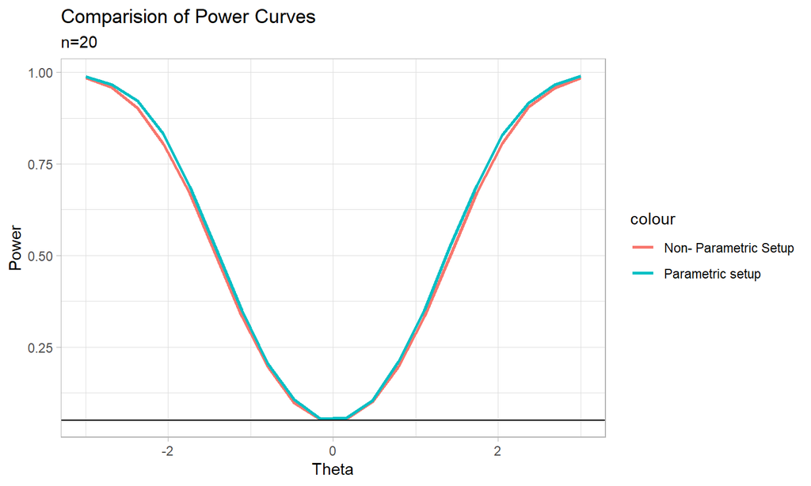

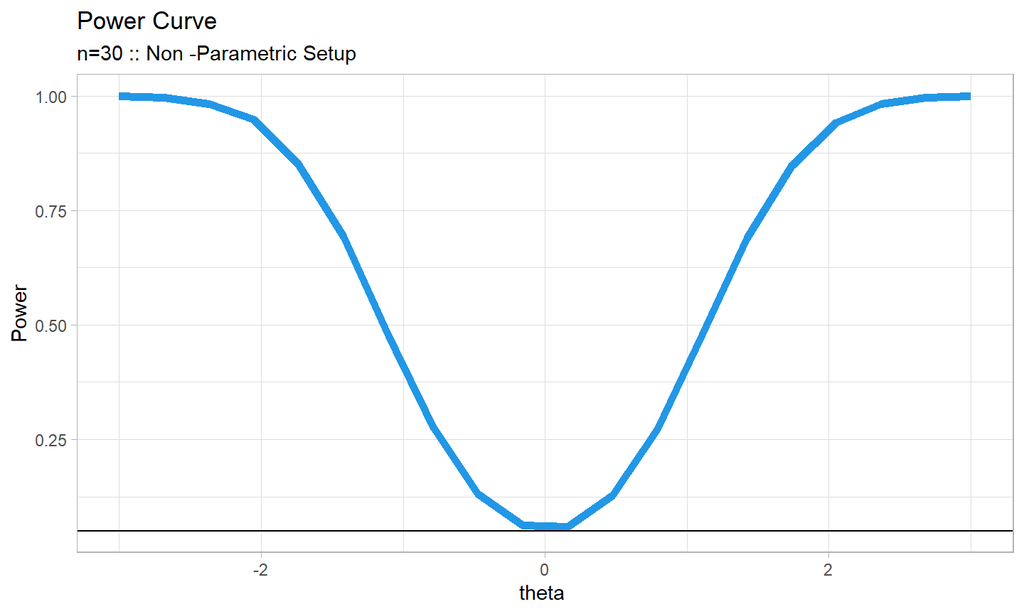

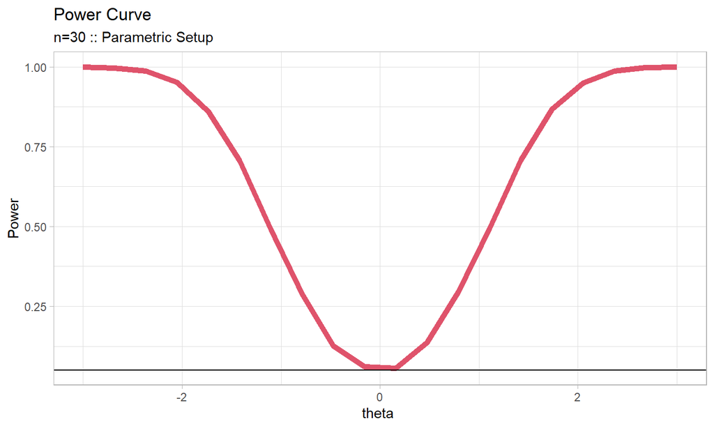

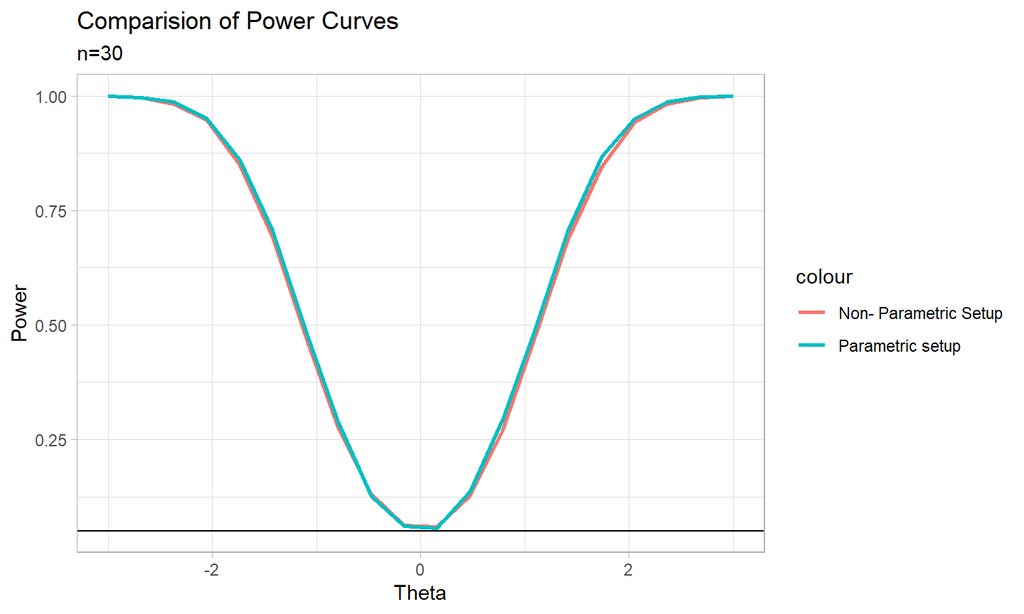

- Observation :

- Considering the t-test , the power curve for the parametric test is converging faster to unity than that of the non-parametric setup for varying sample sizes.
- Increase in sample size leads to faster rate of convergence to unity.
- Both parametric and non-parametric setup shows that the tests are unbiased.

## Parametric Counterpart

- Let us consider the case when a sample of size n is drawn from Cauchy($\mu$,$\sigma$), $\sigma$ > 0 unknown
- H0 : $\mu$ = 0 vs H1 : $\mu$ $\neq$ 0 , $\sigma$ unknown
- Note : The samples are drawn from Cauchy population and t-test is used.

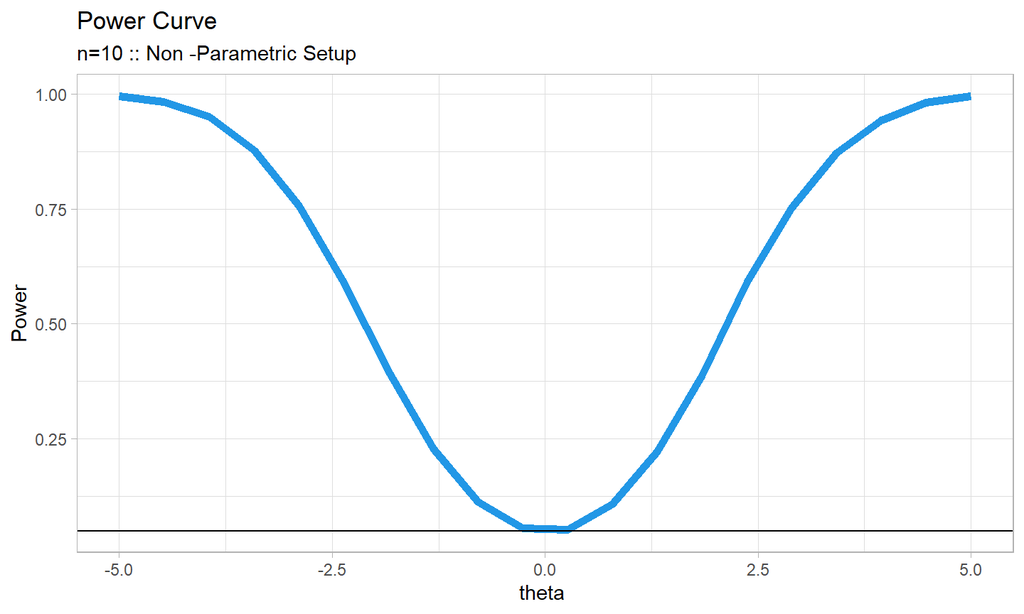

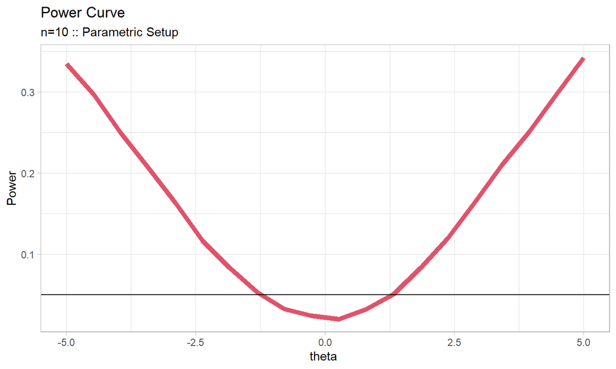

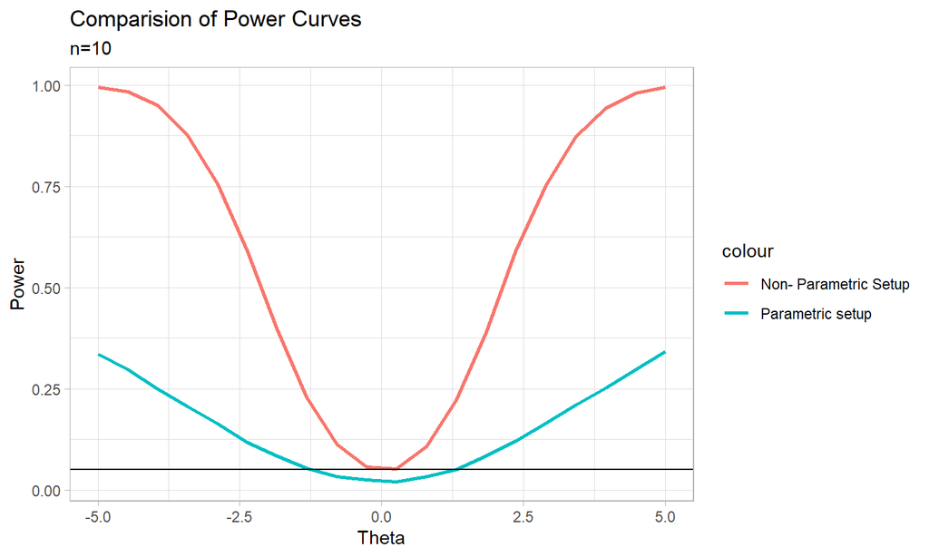

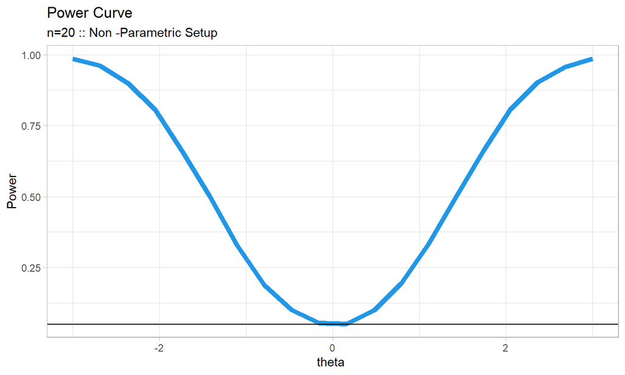

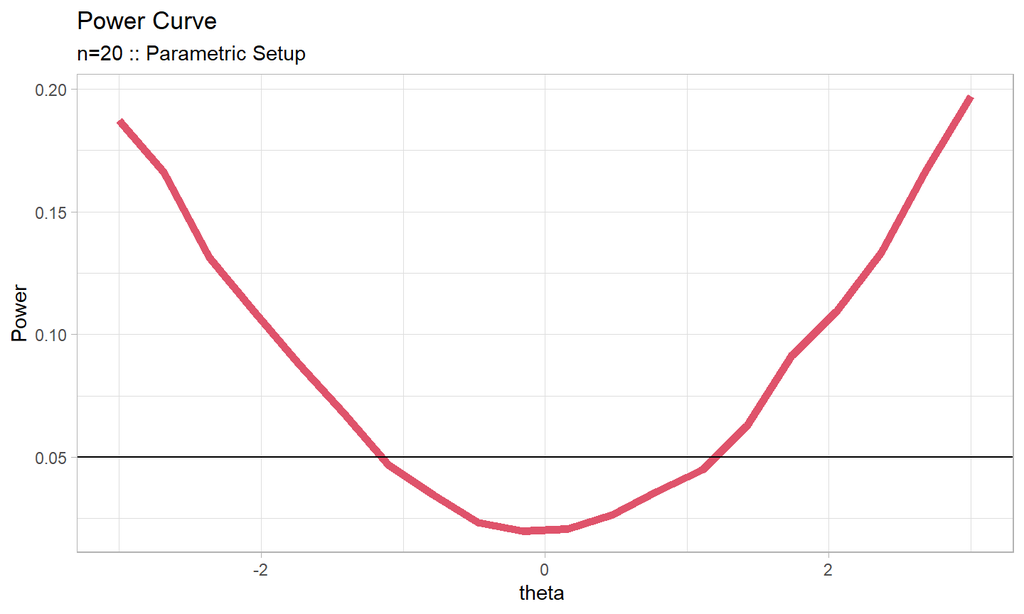

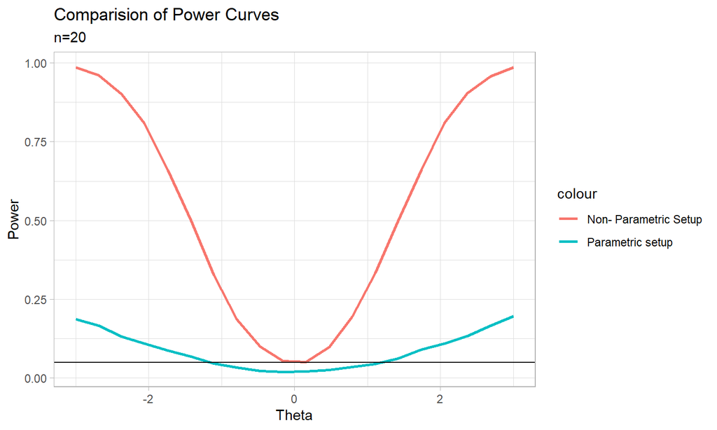

## Test statistic is taken to be Sample Median

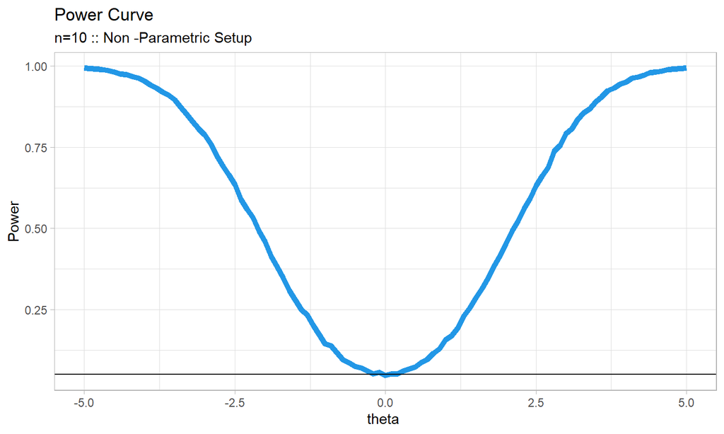

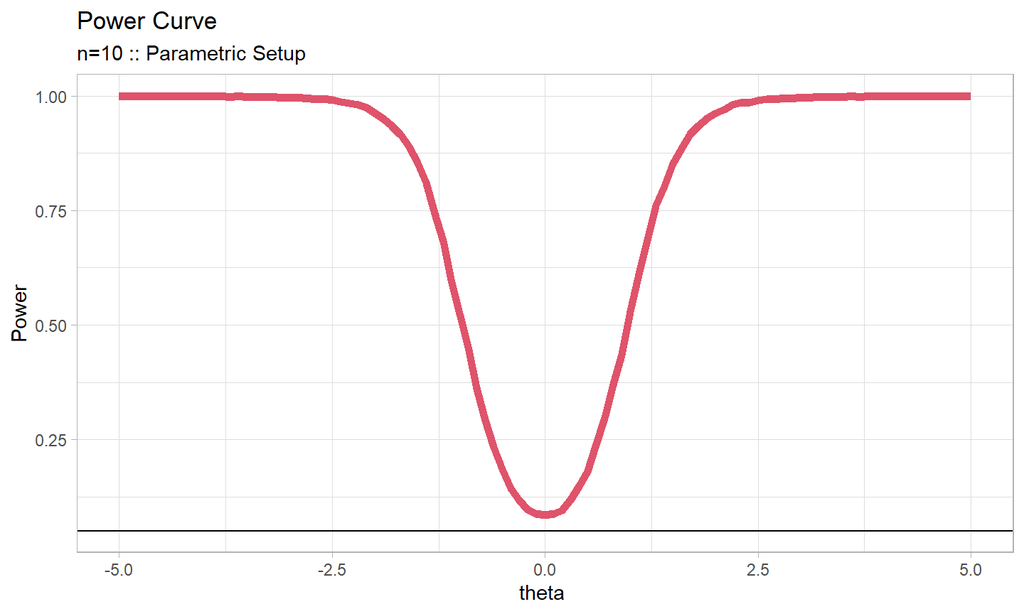

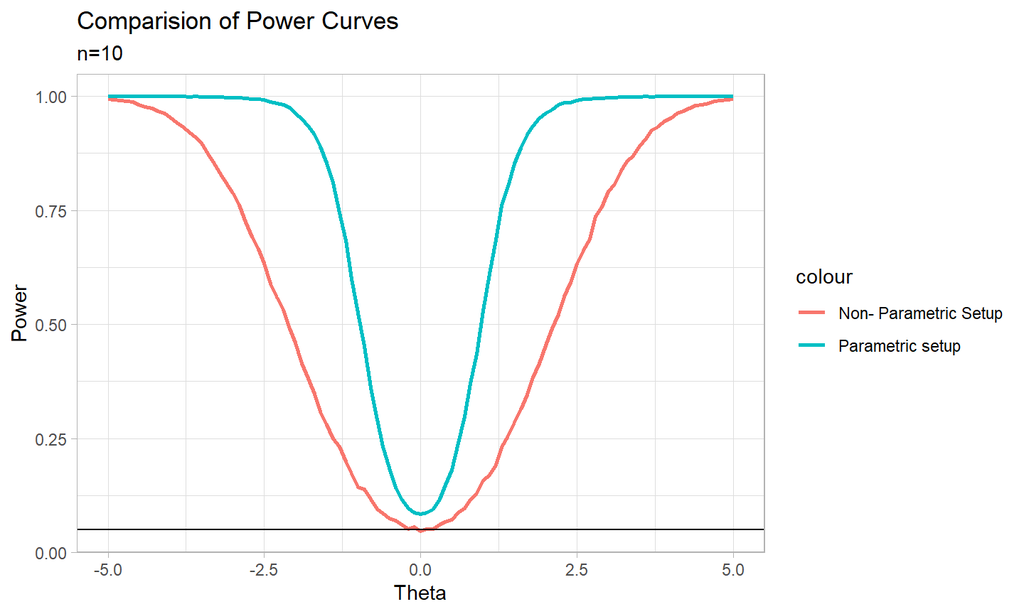

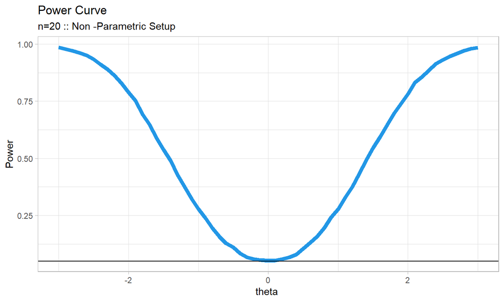

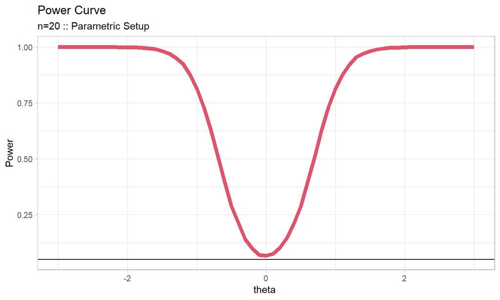

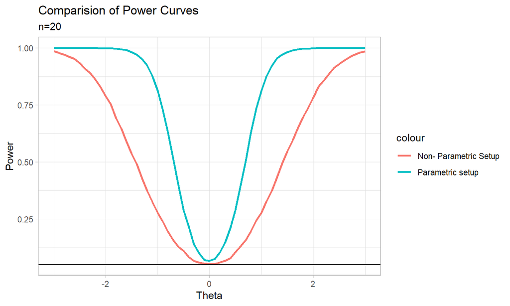

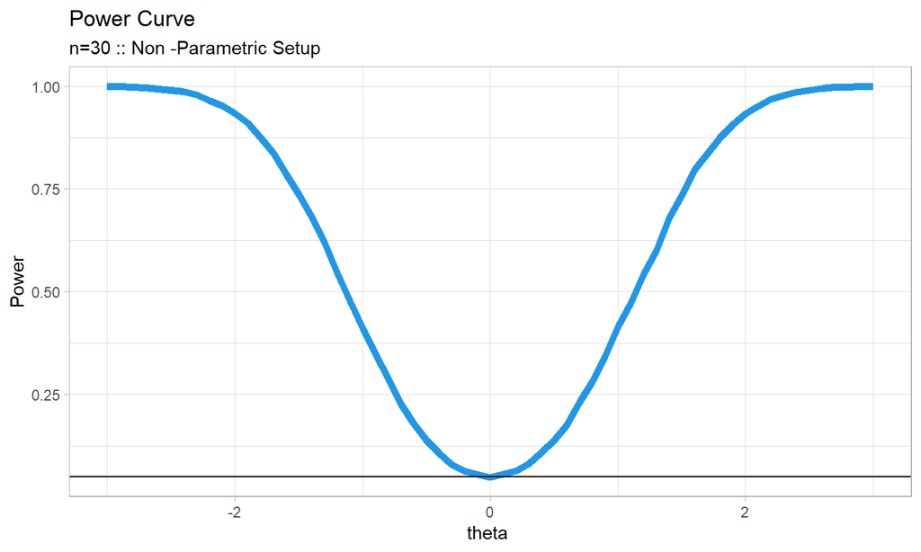

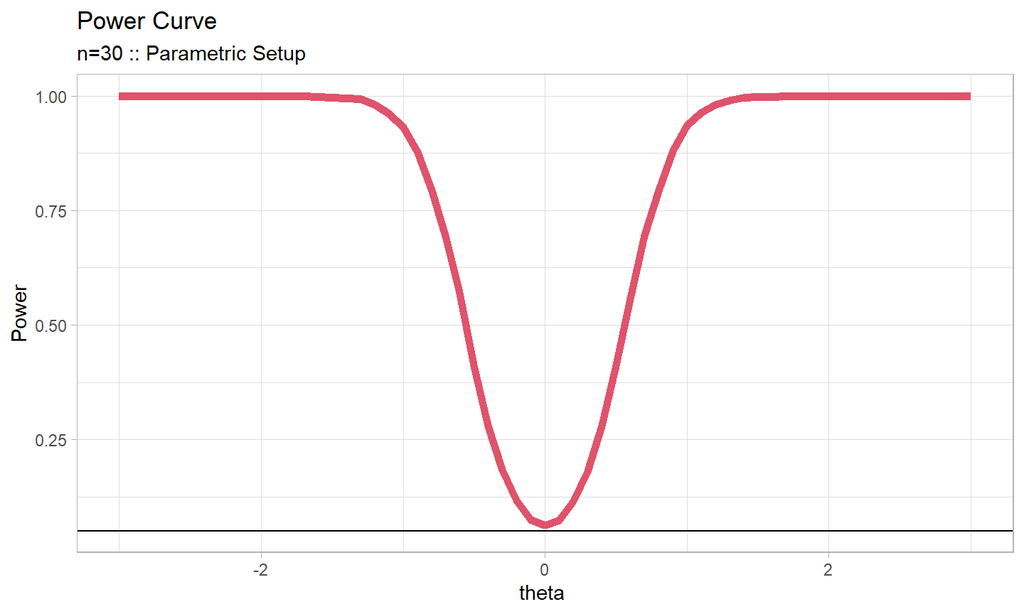

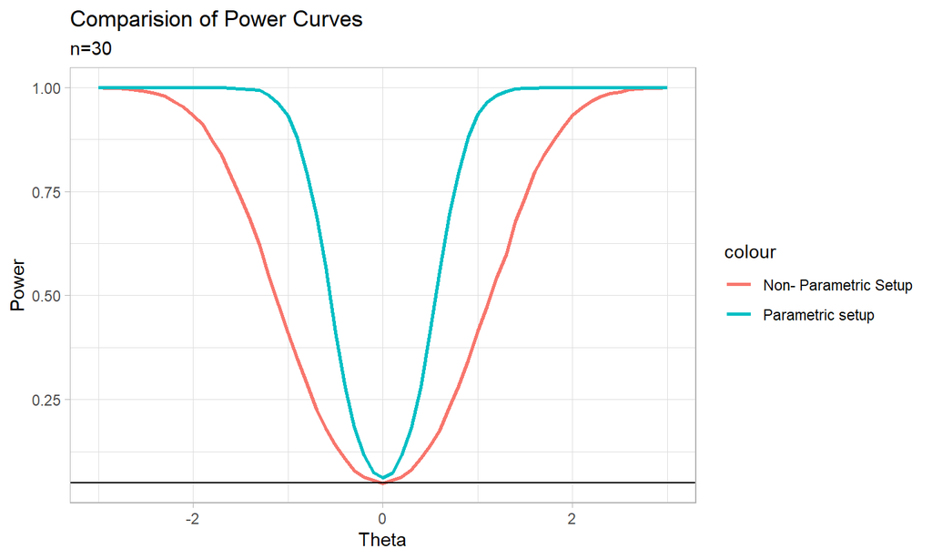

- Observation :
- Considering the asymptotic distribution of median , the power curve for the parametric test is converging faster to unity than that of the non-parametric setup for varying sample sizes.
- Both the scenarios show that the test is unbiased.